# Introduction: Crime Analysis

This project aims to critically evaluate the claims made in **Ross Kemp and the Armed Police** [1] to determine their validity, using Street Level Crime data published by the UK Home Office. The analysis presented in this project will identify trends in crime over time in the United Kingdom, contributing to literature in the Crime and Big Data domain.

## Claims to Evaluate

1. **Violent Crime is increasing.**
2. **Crimes involving firearms are closely associated with drugs offences.**
3. **There are more firearms incidents per head in Liverpool than anywhere else in the UK**

## Approach

1. Process the crime dataset using Apache Spark on a cloud IaaS platform
2. Filter and split the crimes into sets relevant to analyse each claim, combining with additional geographic and population data where necessary.
3. Carry out analysis on the claims made.
   1. Task 1: Determine if violent crimes are increasing by fitting a SARIMA model, and inspecting the trend using time-series decomposition.
   2. Task 2: Use Ordinary Least Squares (OLS) to determine if firearm crime is correlated with drug offences.
   3. Task 2: Determine outlier cities for firearm crime and compare with Liverpool.
      - Perform clustering on cities to give more detailed view.
4. Support analysis with visualisations.
5. Critical discussion of approach.

# 2) Data Pipeline Implementation

```python
import numpy as np
import pandas as pd
import warnings
import itertools
import statsmodels.api as sm
import matplotlib.pyplot as plt
from statsmodels.tsa.stattools import adfuller
from statsmodels.tsa.statespace.sarimax import SARIMAX
from pyspark.sql import SparkSession
from statsmodels.tsa.seasonal import seasonal_decompose
from pyspark.sql import functions as F
from pyspark.ml.stat import Correlation
from pyspark.sql.types import *
import seaborn as sns
from pyspark.ml.clustering import KMeans, BisectingKMeans
from statsmodels.stats.outliers_influence import variance_inflation_factor
from pyspark.ml.feature import VectorAssembler, StandardScaler, PCA
from scipy.stats import kendalltau
from sklearn.metrics import mean_squared_error, mean_absolute_error
from pyspark.ml import Pipeline
import time
from pyspark.ml.evaluation import ClusteringEvaluator
from scipy.stats import zscore
```

```python
spark = SparkSession.builder \
    .appName("kf7032-w21017657") \
    .getOrCreate()
```

[output not shown]

```python
real = "all_crimes21_hdr(5).txt.gz"
test = "Sample_Data_Only_For_Test(2).csv"

schema = StructType([
    StructField("Crime ID", StringType(), True),
    StructField("Month", StringType(), True),
    StructField("Reported by", StringType(), True),
    StructField("Falls within", StringType(), True),
    StructField("Longitude", DoubleType(), True),
    StructField("Latitude", DoubleType(), True),
    StructField("Location", StringType(), True),
    StructField("LSOA code", StringType(), True),
    StructField("LSOA name", StringType(), True),
    StructField("Crime type", StringType(), True),
    StructField("Last outcome category", StringType(), True),
    StructField("Context", StringType(), True)
])

crimes = spark.read.csv(real, schema=schema, header=True)

crimes = crimes.repartition(10)

# Select and rename the only columns used
column_mappings = {
    "Month": "month",
    "LSOA code": "lsoa_code",
    "LSOA name": "lsoa_name",
    "Crime type": "type",
    "Last outcome category": "outcome"
}

renamed_columns = [F.col(col).alias(column_mappings[col]) for col in column_mappings]
crimes = crimes.select(*renamed_columns)

print(crimes.columns)
```

```
['month', 'lsoa_code', 'lsoa_name', 'type', 'outcome']
```

```python
lsoa_df = spark.read.csv("lsoa_pop_v2.csv", inferSchema=True, header=True)

# Rename columns for ease of use
lsoa_column_mappings = {
    "geography": "city",
    "geography code": "lsoa_code",
    "Variable: All usual residents; measures: Value": "total_population",
    "Variable: Density (number of persons per hectare); measures: Value": "density",
}

lsoa_renamed_columns = [F.col(col).alias(lsoa_column_mappings[col]) for col in lsoa_column_mappings]
lsoa_df = lsoa_df.select(*lsoa_renamed_columns)

# Remove the specific code on the end of each city as it isnt used elsewhere
lsoa_df = lsoa_df.withColumn(
    "city_clean", F.regexp_replace("city", r"\s+[0-9A-Za-z]{4}$", "")
)
```

# 3) Data Extraction and Filtering

```python
crime_df = crimes.withColumn("type_lower", F.lower(F.col("type"))) \
                   .withColumn("outcome_lower", F.lower(F.col("outcome")))

# Select distinct types of crime, to find which are violent, drugs related and firearm related
distinct_types = crime_df.select("type_lower").distinct().show(truncate=False)

# Select distinct outcomes to find which would indicate a prison sentence
distinct_outcomes = crime_df.select("outcome_lower").distinct().show(truncate=False)

# Categorise crime data for modelling, given definition of firearm crime.
crime_df = crime_df.withColumn(
    "is_vc",
    F.when(
        (F.col("type_lower").contains("violent")) |
        (F.col("type_lower").contains("violence")),
        True
    ).otherwise(False)
).withColumn(
    "is_firearms",
    F.when(
        (F.col("type_lower").contains("weapon")) &
        (F.col("outcome_lower").contains("prison")),
        True
    ).otherwise(False)
).withColumn(
    "is_drugs",
    F.when(
        F.col("type_lower").contains("drugs") |
        (F.col("outcome_lower").contains("drugs")),
        True
    ).otherwise(False)
).filter((F.col("is_vc") == True) | (F.col("is_firearms") == True) | (F.col("is_drugs") == True)).withColumn(
    "city_clean", F.regexp_replace(F.col("lsoa_name"), r"\s+[0-9A-Za-z]{4}$", "")
).select(
    "month", "is_vc", "is_firearms", "is_drugs", "city_clean", "lsoa_code"
)
```

[output not shown]

```
[Stage 4:>                                                        (0 + 10) / 10]
```

```
+----------------------------+
|type_lower                  |
+----------------------------+
|public disorder and weapons |
|violent crime               |
|other theft                 |
|shoplifting                 |
|violence and sexual offences|
|anti-social behaviour       |
|possession of weapons       |
|burglary                    |
|public order                |
|bicycle theft               |
|criminal damage and arson   |
|vehicle crime               |
|theft from the person       |
|other crime                 |
|robbery                     |
|drugs                       |
+----------------------------+
```

# Claim 1: Violent Crime extraction

```python
# Aggregate crimes by month with number of violent crime incidents for use in SARIMA
vc_count = (
    crime_df.filter(F.col("is_vc"))
    .groupBy("month")
    .count()
    .withColumnRenamed("count", "violent_count")
)

vc_count = (
    month_df.join(vc_count, "month", "left")
    .na.fill({"violent_count": 0})
)

vc_count = vc_count.withColumn("log_violent", F.log1p(F.col("violent_count")))

vc_pd = (
    vc_count.toPandas()
    .assign(
        month=lambda df: pd.to_datetime(df["month"], format="%Y-%m")
    )
    .set_index("month")
    .sort_index()
)

month_df = crime_df.agg(
    F.min("month").alias("min_month"),
    F.max("month").alias("max_month")
).select(
    F.explode(
        F.sequence(
            F.to_date(F.col("min_month"), "yyyy-MM"),
            F.to_date(F.col("max_month"), "yyyy-MM"),
            F.expr("interval 1 month")
        )
    ).alias("month")
)
```

For time-series extraction the data should be stationary [14], an Augmented Dickey Fuller test can check this and apply differencing to achieve stationarity [2].

```python
# For some reason the first time i execute an adf_test on a fresh kernel it doesnt work first time
def adf_test(series, retries=3, delay=1):
    for attempt in range(retries):
        try:
            result = adfuller(series, maxlag=6)
            print("ADF Statistic:", result[0])
            print("p-value:", result[1])
            print("Critical Values:", result[4])
            return result[1]
        except np.linalg.LinAlgError:
            print(f"Attempt {attempt + 1} fail: SVD didnt converge")
            time.sleep(delay)
    raise ValueError("ADF test failed completely.")

# ADF on log_violent
print("=== ADF Test on log_violent ===")
adf_test(vc_pd["log_violent"])

# Create first difference
vc_pd["diff"] = vc_pd["log_violent"].diff()
vc_pd.dropna(subset=["diff"], inplace=True)

# ADF on first difference
print("\n=== ADF Test on first difference ===")
adf_test(vc_pd["diff"])
```

```
=== ADF Test on log_violent ===
Attempt 1 fail: SVD didnt converge
ADF Statistic: -0.4448122164386527
p-value: 0.902343612819088
Critical Values: {'1%': -3.484219653271961, '5%': -2.885145235641637, '10%': -2.579359138917794}

=== ADF Test on first difference ===
ADF Statistic: -6.26413981086909
p-value: 4.1536441159990733e-08
Critical Values: {'1%': -3.4865346059036564, '5%': -2.8861509858476264, '10%': -2.579896092790057}
```

```
4.1536441159990733e-08
```

# Claim 2 and 3, Firearm and drug extraction

```python
# Get only the relevant crimes
aggregated_crime_df = crime_df.groupBy("lsoa_code").agg(
    F.count(F.when(F.col("is_firearms"), 1)).alias("firearm_incidents"),
    F.count(F.when(F.col("is_drugs"), 1)).alias("drug_incidents"),
    F.count(F.when(F.col("is_vc"), 1)).alias("vc_incidents")
)

# broadcast join on relevant crimes
incidents_lsoa_joined = F.broadcast(lsoa_df).join(
    aggregated_crime_df, "lsoa_code", "left"
).fillna(
    {"firearm_incidents": 0, "drug_incidents": 0, "vc_incidents": 0}
)

city_agg = (
    incidents_lsoa_joined
    .groupBy("city_clean")
    .agg(
        F.sum("firearm_incidents").alias("total_firearm_incidents"),
        F.sum("drug_incidents").alias("total_drug_incidents"),
        F.sum("vc_incidents").alias("total_vc_incidents"),
        F.sum("total_population").alias("total_population"),
        F.avg("density").alias("avg_density"),
    )
    .filter("total_population > 0")
    .withColumn("firearm_incidents_per_1000", (F.col("total_firearm_incidents") / F.col("total_population")) * 1000)
    .withColumn("drug_incidents_per_1000", (F.col("total_drug_incidents") / F.col("total_population")) * 1000)
    .withColumn("vc_incidents_per_1000", (F.col("total_vc_incidents") / F.col("total_population")) * 1000)
    .withColumn("is_liverpool", F.col("city_clean").rlike("(?i)Liverpool"))
    .withColumn("log_firearm", F.log1p("total_firearm_incidents"))
    .withColumn("log_drug", F.log1p("total_drug_incidents"))
    .withColumn("log_vc", F.log1p("total_vc_incidents"))
    .withColumn("log_density", F.log1p("avg_density"))
    .withColumn("log_pop", F.log1p("total_population"))
)
```

# 4) Design, Development and reasoning behind use of multiple visualization methods, statistics, and machine learning models

# Claim 1: Violent Crime is increasing

## Diagnostic Figure: Yearly Violent Crime: COVID-19 Dip.

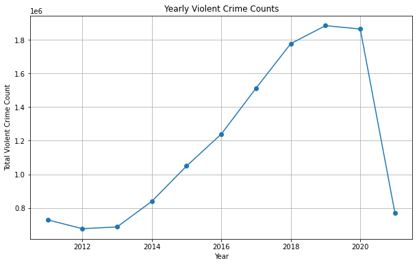

```python
vc_pd["year"] = vc_pd.index.year
yearly_vc = vc_pd.groupby("year")["violent_count"].sum()

plt.figure(figsize=(10, 6))
plt.plot(yearly_vc.index, yearly_vc.values, marker='o')
plt.title("Yearly Violent Crime Counts")
plt.xlabel("Year")
plt.ylabel("Total Violent Crime Count")
plt.grid(True)
plt.show()
```

- Kendall Test to test for upward trend in crime rates [18].
- **Visualisation 1** comparison between the real crime counts (log-transformed) and the SARIMA-generated forecasts.
- Assess accuracy using Root Mean Square Error (RMSE) and Mean Absolute Error (MAE).

This approach aligns with existing literature that emphasises the importance of preventing data from the forecasted period being included in the training data to prevent overly optimistic model evaluations [17].

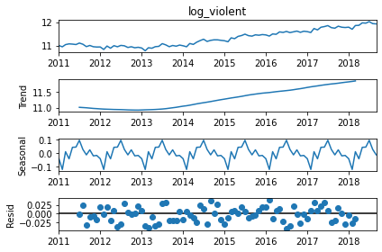

```
Kendall Tau: 0.7573632538569424, p-value: 5.7371921186723644e-27
Significant trend detected in the data.
```

```python
train_end_date = '2018-09-30'
test_start_date = '2018-10-01'
test_end_date = '2021-09-30'

train_data = vc_pd.loc[:train_end_date]
test_data = vc_pd.loc[test_start_date:test_end_date]

# diagnostics check for seasonality trends
decomposition = seasonal_decompose(train_data["log_violent"], model='additive', period=12)
trend = decomposition.trend
residual = decomposition.resid
seasonal = decomposition.seasonal

decomposition.plot()
plt.show()

# Use the index time as X and the log transformed violent crime data as Y
# Converts dates into integers
x = train_data.index.factorize()[0]
y = train_data["log_violent"].dropna()

# perform Kendall Tau test
tau, p_value = kendalltau(x, y)
print(f"Kendall Tau: {tau}, p-value: {p_value}")

# interpret
if p_value < 0.05:
    print("Significant trend detected in the data.")
else:
    print("No significant trend detected in the data.")

# fit SARIMA on training data once differenced
violent_model = SARIMAX(
    train_data["diff"],
    order=(1, 1, 1),
    seasonal_order=(1, 1, 1, 12),
    enforce_stationarity=False,
    enforce_invertibility=False
)

violent_results = violent_model.fit(disp=False)
```

```python
# Forecast
forecast_steps = len(test_data)
forecast_obj = violent_results.get_forecast(steps=forecast_steps)
forecast_diff = forecast_obj.predicted_mean
forecast_diff_ci = forecast_obj.conf_int()

last_log_value_train = train_data["log_violent"].iloc[-1]
forecast_log_test = forecast_diff.cumsum() + last_log_value_train
actual_log_test = test_data["log_violent"]

# Evaluate the models accuracy
rmse = np.sqrt(mean_squared_error(actual_log_test, forecast_log_test))
mae = mean_absolute_error(actual_log_test, forecast_log_test)
print(f"Overall test RMSE: {rmse}")
print(f"Overall test MAE: {mae}")

# RMSE for two periods
test_period_1_end = '2019-09-30'
test_period_2_start = '2019-10-01'

# Split test data
test_data_period_1 = test_data.loc[:test_period_1_end]
test_data_period_2 = test_data.loc[test_period_2_start:test_end_date]


def forecast_actual(data_period, period):
    forecast = forecast_log_test.loc[data_period.index]
    actual = actual_log_test.loc[data_period.index]

    rmse = np.sqrt(mean_squared_error(actual, forecast))
    print(f"RMSE for Period {period} (First 12 months): {rmse:.4f}")

forecast_actual(test_data_period_1, 1)
forecast_actual(test_data_period_2, 2)

# future forecasts beyond test period
forecast_obj_future = violent_results.get_forecast(steps=forecast_steps)
forecast_diff_future = forecast_obj_future.predicted_mean
forecast_diff_future_ci = forecast_obj_future.conf_int()

last_log_value = vc_pd["log_violent"].iloc[-1]
forecast_log_future = forecast_diff_future.cumsum() + last_log_value
forecast_counts_lower_future = forecast_diff_future_ci.iloc[:, 0].cumsum() + last_log_value
forecast_counts_upper_future = forecast_diff_future_ci.iloc[:, 1].cumsum() + last_log_value

# prepare future dates
forecast_index_future = pd.date_range(
    start=vc_pd.index[-1] + pd.offsets.MonthBegin(1),
    periods=forecast_steps,
    freq='MS'
)
```

```
Overall test RMSE: 0.28768960491832235
Overall test MAE: 0.2421871941440461
RMSE for Period 1 (First 12 months): 0.1033
RMSE for Period 2 (First 12 months): 0.3550
```

## Visualisation 1

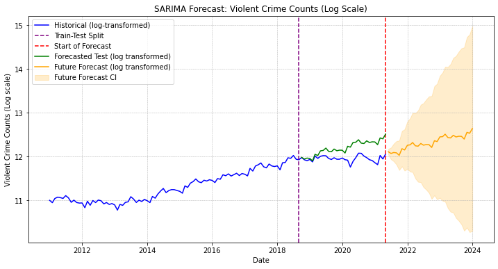

```python
# Visualisation 1, the historical data, forecasts at log scale
plt.figure(figsize=(12, 6))
plt.plot(vc_pd.index, vc_pd["log_violent"], label="Historical (log-transformed)", color="blue")
plt.axvline(train_data.index[-1], color='purple', linestyle='--', label="Train-Test Split")
plt.axvline(vc_pd.index[-1], color='red', linestyle='--', label="Start of Forecast")
plt.plot(test_data.index, forecast_log_test, label="Forecasted Test (log transformed)", color="green")
plt.plot(forecast_index_future, forecast_log_future, label="Future Forecast (log transformed)", color="orange")
plt.fill_between(
    forecast_index_future,
    forecast_counts_lower_future,
    forecast_counts_upper_future,
    color="orange",
    alpha=0.2,
    label="Future Forecast CI"
)
plt.title("SARIMA Forecast: Violent Crime Counts (Log Scale)")
plt.xlabel("Date")
plt.ylabel("Violent Crime Counts (Log scale)")
plt.legend()
plt.grid(visible=True, which="both", linestyle="--", linewidth=0.5)
plt.show()
```

# Claim 2: Gun crime is associated with drug crime.

To test this claim a Pearson correlation between drug and firearm crime is calculated. Following establishing this relationship, Ordinary Least Squares (OLS) regression is used to determine the influence of additional features on this relationship. Pearson correlation measures the strength and direction of the linear relationship, while OLS will esimate the coefficients between the explanatory and dependent variable [15].

```python
feature_cols = feature_cols = ["log_drug", "log_firearm"]

correlation_matrix = Correlation.corr(
    VectorAssembler(inputCols=feature_cols, outputCol="corr_features")
    .transform(city_agg)
    .select("corr_features"),
    "corr_features",
    "pearson"
).head()[0].toArray()

print("Pearson correlation matrix:\n", correlation_matrix)
```

```
Pearson correlation matrix:
 [[1.         0.87957355]
 [0.87957355 1.        ]]
```

```
25/01/30 00:46:22 WARN InstanceBuilder$NativeBLAS: Failed to load implementation from:dev.ludovic.netlib.blas.JNIBLAS
25/01/30 00:46:22 WARN InstanceBuilder$NativeBLAS: Failed to load implementation from:dev.ludovic.netlib.blas.ForeignLinkerBLAS
```

```python
city_agg_pdf = city_agg.toPandas()

def ols_and_vif(features, target):
    X = city_agg_pdf[features]
    X = sm.add_constant(X)

    y = city_agg_pdf[target]

    ols_model = sm.OLS(y, X).fit()

    print(ols_model.summary())

    # calculate VIF for features
    vif_data = pd.DataFrame()
    vif_data["feature"] = X.columns
    vif_data["VIF"] = [variance_inflation_factor(X.values, i) for i in range(X.shape[1])]

    return vif_data, ols_model


vif_firearm_target, f_model = ols_and_vif(
    ["log_density", "log_vc", "log_drug"], "log_firearm"
)
vif_drug_target, d_model = ols_and_vif(
    ["log_density", "log_vc", "log_firearm"], "log_drug"
)
```

```
[Stage 61:>                                                       (0 + 10) / 10]
```

```
                            OLS Regression Results
==============================================================================
Dep. Variable:            log_firearm   R-squared:                       0.818
Model:                            OLS   Adj. R-squared:                  0.816
Method:                 Least Squares   F-statistic:                     514.9
Date:                Thu, 30 Jan 2025   Prob (F-statistic):          8.35e-127
Time:                        00:48:34   Log-Likelihood:                -236.20
No. Observations:                 348   AIC:                             480.4
Df Residuals:                     344   BIC:                             495.8
Df Model:                           3
Covariance Type:            nonrobust
===============================================================================
                  coef    std err          t      P>|t|      [0.025      0.975]
-------------------------------------------------------------------------------
const          -7.5961      0.392    -19.391      0.000      -8.367      -6.826
log_density     0.1104      0.060      1.854      0.065      -0.007       0.228
log_vc          0.7048      0.081      8.744      0.000       0.546       0.863
log_drug        0.4838      0.076      6.396      0.000       0.335       0.633
==============================================================================
Omnibus:                       19.759   Durbin-Watson:                   1.839
Prob(Omnibus):                  0.000   Jarque-Bera (JB):               42.224
Skew:                          -0.274   Prob(JB):                     6.78e-10
Kurtosis:                       4.616   Cond. No.                         209.
==============================================================================

Notes:
[1] Standard Errors assume that the covariance matrix of the errors is correctly specified.
                            OLS Regression Results
==============================================================================
Dep. Variable:               log_drug   R-squared:                       0.868
Model:                            OLS   Adj. R-squared:                  0.867
Method:                 Least Squares   F-statistic:                     755.2
Date:                Thu, 30 Jan 2025   Prob (F-statistic):          6.02e-151
Time:                        00:48:34   Log-Likelihood:                -98.858
No. Observations:                 348   AIC:                             205.7
Df Residuals:                     344   BIC:                             221.1
Df Model:                           3
Covariance Type:            nonrobust
===============================================================================
                  coef    std err          t      P>|t|      [0.025      0.975]
-------------------------------------------------------------------------------
const           0.0657      0.382      0.172      0.864      -0.685       0.817
log_density     0.2253      0.038      5.858      0.000       0.150       0.301
log_vc          0.6236      0.050     12.530      0.000       0.526       0.721
log_firearm     0.2197      0.034      6.396      0.000       0.152       0.287
==============================================================================
Omnibus:                       20.727   Durbin-Watson:                   1.992
Prob(Omnibus):                  0.000   Jarque-Bera (JB):               25.839
Skew:                           0.499   Prob(JB):                     2.45e-06
Kurtosis:                       3.886   Cond. No.                         256.
==============================================================================

Notes:
[1] Standard Errors assume that the covariance matrix of the errors is correctly specified.
```

# Claim 3: There are more gun crimes per person in Liverpool than other areas in the UK.

Outlier cities are plotted for firearm crime with their per capita rates and raw numbers, revealing if the claim is true or false. Following this Principal Compoent Analysis (PCA) is performed to reduce the dimensionality of the dataset. This is followed by K-Means clustering to group cities into clusters based on patterns in their features. A scatterplot of the PCA components with clustered highlighted will be produces, allowing for interpretation of Liverpool's position relative to other cities for firearm and related crime.

```python
# Identify 95th percentile outliers for firearm incidents
firearm_threshold = city_agg_pdf["firearm_incidents_per_1000"].quantile(0.95)


city_agg_pdf['is_firearm_outlier'] = city_agg_pdf["firearm_incidents_per_1000"] > firearm_threshold

# Select only rows that are firearm outliers
firearm_outliers_df = city_agg_pdf[city_agg_pdf['is_firearm_outlier'] == True]['city_clean']

# From city_agg_pdf get only the outlying citys
filtered_city_agg = city_agg_pdf[city_agg_pdf["city_clean"].isin(firearm_outliers_df.tolist())]

filtered_city_agg = filtered_city_agg.reset_index().sort_values("firearm_incidents_per_1000", ascending=False)
```

## Visualisation 2

[figure not shown]

```python
# Visualisation 2: Bar and line graph of total firearm incidents and rate per 1000
fig, ax1 = plt.subplots(figsize=(12, 8))

bar_width = 0.8
cities = filtered_city_agg["city_clean"]

x = np.arange(len(cities))

# bar charts for rate per capita
ax1.bar(x, filtered_city_agg["firearm_incidents_per_1000"], width=bar_width, label="Incident Count", alpha=0.7)
ax1.set_ylabel("Firearm Incidents Per 1000", fontsize=12)
ax1.set_xlabel("City", fontsize=12)
ax1.set_title("Firearm Incident Rate and Incident Count by City", fontsize=14)
ax1.set_xticks(x)
ax1.set_xticklabels(cities, rotation=45, ha="right")
ax1.grid(visible=True, which='both', linestyle='--', linewidth=0.5, alpha=0.7)

# Line graph for total incidents
ax2 = ax1.twinx()
ax2.plot(x, filtered_city_agg["total_firearm_incidents"], color="r", marker="o", label="Incidents per 1000", linewidth=2)
ax2.set_ylabel("Total Firearm Incidents", fontsize=12)

# move the legends out the plotted area because they get in the way
ax1.legend(loc="upper left", bbox_to_anchor=(0, 1.15), title="Bar Legend")
ax2.legend(loc="upper right", bbox_to_anchor=(1, 1.15), title="Line Legend")

plt.tight_layout()
plt.show()
```

# K-Means Clustering

```python
# Add 1 to the raw firearm data before applying log, gives better results
city_agg = city_agg.withColumn("log_firearm_adjusted", F.col("log_firearm") + F.lit(1))

# Step 1: Prepare features
feature_cols = ["log_firearm_adjusted", "log_drug", "log_density"]
assembler = VectorAssembler(inputCols=feature_cols, outputCol="features")
scaler = StandardScaler(inputCol="features", outputCol="scaled_features")
pca = PCA(k=2, inputCol="scaled_features", outputCol="pca_features")

kmeans = BisectingKMeans(featuresCol="pca_features", k=4, seed=2003, predictionCol="cluster")
pipeline = Pipeline(stages=[assembler, scaler, pca, kmeans])
model = pipeline.fit(city_agg)

city_agg_pca_kmeans = model.transform(city_agg)
city_agg_pca_kmeans.select("city_clean", "pca_features", "cluster").show(5, truncate=False)

city_agg_pdf = city_agg_pca_kmeans.toPandas()

# extract Liverpool
liverpool_pca = city_agg_pdf[city_agg_pdf["city_clean"] == "Liverpool"]
liverpool_x = liverpool_pca["pca_features"].apply(lambda x: x[0]).values[0]
liverpool_y = liverpool_pca["pca_features"].apply(lambda x: x[1]).values[0]
```

```
25/01/30 00:53:01 WARN LAPACK: Failed to load implementation from: com.github.fommil.netlib.NativeSystemLAPACK
25/01/30 00:53:01 WARN LAPACK: Failed to load implementation from: com.github.fommil.netlib.NativeRefLAPACK
```

```
+--------------+-----------------------------------------+-------+
|city_clean    |pca_features                             |cluster|
+--------------+-----------------------------------------+-------+
|Worcester     |[-11.633445591337113,0.4536069542553074] |1      |
|Charnwood     |[-10.608316694187264,0.4611653956369892] |2      |
|North Kesteven|[-8.592565882161262,0.7140141454798576]  |3      |
|Epping Forest |[-10.435037642137743,0.46074577985522325]|2      |
|Waveney       |[-10.363757800124572,0.23500902340346297]|2      |
+--------------+-----------------------------------------+-------+
only showing top 5 rows
```

## Visualisation 3

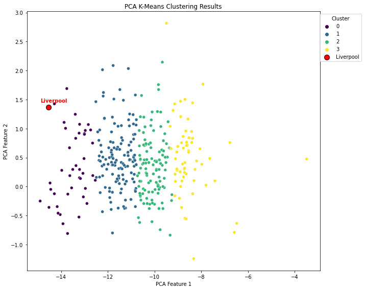

```
[Stage 438:>                                                      (0 + 10) / 10]
```

```
+-------+-----------------+-----------------+------------------+-----+
|cluster|avg_log_firearm  |avg_log_drug     |avg_log_density   |count|
+-------+-----------------+-----------------+------------------+-----+
|0      |5.500521382815478|9.550609916979   |4.389824465149183 |43   |
|1      |4.439966196330416|8.393539260807316|3.6062856753616592|131  |
|2      |3.366299590828491|7.625336188602655|3.1710148846830997|113  |
|3      |2.293235398456378|6.913860140033459|2.5074919353488805|61   |
+-------+-----------------+-----------------+------------------+-----+
```

```python
plt.figure(figsize=(10, 8))
sns.scatterplot(
    x=city_agg_pdf["pca_features"].apply(lambda x: x[0]),
    y=city_agg_pdf["pca_features"].apply(lambda x: x[1]),
    hue=city_agg_pdf["cluster"],
    palette="viridis",
    legend="full"
)

# Annotate Liverpool
plt.scatter(liverpool_x, liverpool_y, color="red", label="Liverpool", edgecolor="black", s=100)
plt.annotate(
    "Liverpool",
    (liverpool_x, liverpool_y),
    textcoords="offset points",
    xytext=(10, 10),
    ha="center",
    fontsize=10,
    color="red",
    fontweight="bold"
)

plt.title("PCA K-Means Clustering Results")
plt.xlabel("PCA Feature 1")
plt.ylabel("PCA Feature 2")
plt.legend(title="Cluster", loc="upper right", bbox_to_anchor=(1.15, 1))
plt.tight_layout()

plt.show()

cluster_means = (
    city_agg_pca_kmeans.groupBy("cluster")
    .agg(
        F.avg("log_firearm").alias("avg_log_firearm"),
        F.avg("log_drug").alias("avg_log_drug"),
        F.avg("log_density").alias("avg_log_density"),
        F.count("*").alias("count")
    )
    .orderBy("cluster")
)

# Show the cluster means
cluster_means.show(truncate=False)
```

# 5) Selection, application, and reasoning behind use of statistical analysis and multiple evaluation measures

## Claim 1: Violent Crime is increasing.

```python
def compare_years(y1, y2):
    vc1 = yearly_vc.loc[y1]
    vc2 = yearly_vc.loc[y2]

    increase = ((vc2 - vc1) / vc1) * 100
    print(f"Violent crime increased by {increase:.2f}% between the years {y1} and {y2}")

compare_years(2019, 2020)
compare_years(2020, 2021)
compare_years(2011, 2019)
```

```
Violent crime increased by -1.05% between the years 2019 and 2020
Violent crime increased by -58.77% between the years 2020 and 2021
Violent crime increased by 158.27% between the years 2011 and 2019
```

### SARIMA Model Results

SARIMA[12] was to capture monthly seasonality and forecasting ability.

- 80/20 Train/Test split
- Differencing was applied to remove trends and achieve stationarity tested using the Augmented-Dickey Fuller Test.
- Seasonal decomposition revealed significant periodic components, supporting the use of seasonal parameters.
- Without exogenous variables, the models ability to account for external shocks is limited. Future iterations would explore using House Price Index data and other factors.
- This modelling does not account for the different rates of growth in different regions.

```python
print(violent_results.summary())
```

```
                                     SARIMAX Results
==========================================================================================
Dep. Variable:                               diff   No. Observations:                   93
Model:             SARIMAX(1, 1, 1)x(1, 1, 1, 12)   Log Likelihood                 127.937
Date:                            Thu, 30 Jan 2025   AIC                           -245.874
Time:                                    01:06:40   BIC                           -234.926
Sample:                                01-01-2011   HQIC                          -241.548
                                     - 09-01-2018
Covariance Type:                              opg
==============================================================================
                 coef    std err          z      P>|z|      [0.025      0.975]
------------------------------------------------------------------------------
ar.L1         -0.2615      0.115     -2.273      0.023      -0.487      -0.036
ma.L1         -0.9281      0.074    -12.492      0.000      -1.074      -0.782
ar.S.L12      -0.2451      0.168     -1.456      0.145      -0.575       0.085
ma.S.L12      -0.4862      0.230     -2.118      0.034      -0.936      -0.036
sigma2         0.0011      0.000      5.389      0.000       0.001       0.002
===================================================================================
Ljung-Box (L1) (Q):                   0.32   Jarque-Bera (JB):                 0.38
Prob(Q):                              0.57   Prob(JB):                         0.83
Heteroskedasticity (H):               0.39   Skew:                             0.12
Prob(H) (two-sided):                  0.03   Kurtosis:                         3.29
===================================================================================

Warnings:
[1] Covariance matrix calculated using the outer product of gradients (complex-step).
```

## Claim 2: Firearm and drug crime

### Ordinary Least Squares Evaluation

To explore the association between gun crime and drug crime, Ordinary Least Squares (OLS) regression was applied to validate these findings and explore the relationship.

#### Preparation

1. Predictors included log-transformed variables: drug crime `log_drug`, violent crime `log_vc`, and population density `log_density`.
2. Features were log transofrmed to address the skew in data and ensure stable variance in relationships [23].
3. Two seperate models are created, targeting `log_drug` and `log_firearm`.

#### Model 1: Predicting Firearm Crime `log_firearm`

- Adjusted R-squared: `0.816`: 81.6% of the variability in firearm crime is explained by the predictors.

##### Coefficients

- Violent crime: strong positive association `0.7048`.
- Drug crime: significant positive association but weaker than violent crime `0.4838`.
- Population density: weaker and insignificant relationship `0.1104`.

##### Model Fit:

- **AIC**: `480.4`
- **BIC**: `495.8`

#### Model 2: Predicting Drug Crime `log_drug`

- Adjusted R-squared: `0.867`: 86.7% of the variability in drug crime is explained by the predictors.

##### Model Fit:

- **AIC**: `205.7`
- **BIC**: `221.1`.
1. Firearm crime is more strongly influenced by drug crime than drug crime is by firearm crime.
2. Violent crime is more strongly associated with firearm crime (coefficient = `0.7048`) than drug crime (coefficient = 0.6236).
3. Population density is a stronger predictor for drug crime (coefficient = `0.2253`) compared to firearm crime (coefficient = 0.1104, p-value = 0.065). This suggests that areas with higher population densities may contribute more to drug activity more than firearm activity.
   - The drug crime model (AIC = 205.7, BIC = 221.1) fits better than the firearm model (AIC = 480.4, BIC = 495.8).
4. The optimum number of clusters is not determined using a statistical method such as **Elbow Method** [12] or **Sillhouette Score** to ensure proper cluster fit [13].
5. Multicollinearity between log_vc and log_drug suggests these features could be combined, as they have VIF scores both higher than 5.

```python
print(vif_drug_target)
print(vif_firearm_target)
```

```
       feature         VIF
0        const  485.541354
1  log_density    2.084780
2       log_vc    5.014462
3  log_firearm    4.906511
       feature         VIF
0        const  232.001036
1  log_density    2.270042
2       log_vc    5.975077
3     log_drug    6.779662
```

# Claim 3: There are more gun crimes per person in Liverpool than other areas in the UK.

## Visualisation:

1. Bar chart and line graph: This visualisation showed the incidents rates along with the total number of incidents, to challenge the claim that Liverpool has a higher rate of firearm crime than other areas.
2. Scatter Plot: A scatter plot visualised the clusters in the PCA-reduced feature space, with points colored by cluster assignment. Liverpool was specifically highlighted and annotated in red to examine its position relative to other cities.

```python
city_agg_pdf['zscore_firearm_per_1000'] = zscore(city_agg_pdf['firearm_incidents_per_1000'])
city_agg_pdf['zscore_firearm_raw'] = zscore(city_agg_pdf['total_firearm_incidents'])

city_agg_pdf['zscore_drug_per_1000'] = zscore(city_agg_pdf['drug_incidents_per_1000'])
city_agg_pdf['zscore_drug_raw'] = zscore(city_agg_pdf['total_drug_incidents'])


def zscore_for_place(place):
    place_zscore = city_agg_pdf[city_agg_pdf['city_clean'] == place]
    print(f"{place} Z-Score for Firearm Incidents: {place_zscore['zscore_firearm_raw'].iloc[0]:.2f}")
    print(f"{place} Z-Score for Firearm Incidents per 1000: {place_zscore['zscore_firearm_per_1000'].iloc[0]:.2f}")

zscore_for_place("Liverpool")

evaluator = ClusteringEvaluator(
    featuresCol="pca_features",
    predictionCol="cluster",
    metricName="silhouette",
    distanceMeasure="squaredEuclidean"
)
silhouette = evaluator.evaluate(city_agg_pca_kmeans)
print(f"Silhouette Score: {silhouette:.4f}")
```

[output not shown]

```
[Stage 471:>                                                      (0 + 10) / 10]
```

```
Silhouette Score: 0.5334
```

1. K-Means Clustering clusters Liverpool as higher firearm rate cities cluster.
2. Liverpool is in the 18 cities in the 95 percentile of worst cities for firearm rate per capita.
3. Liverpool has the highest total incidents of any city.

```python
spark.stop()
```

# 6) Analysis of the appropriateness of the solution

The proposed solution leverages Apache Spark for computationally intensive tasks and converting to Pandas DataFrames for analysis. This ensuring efficient processing of big data. Integration ofpopulation data enabled per capita analysis reducing the skew of larger population density [6]. SARIMA implementation could be improved by using exogoneous variables. OLS regression then explored the strength and interaction of additional variables, giving a comprehensive statistical foundation. In addition VIF analysis addressed multicollinearity, enhancing the reliability of insights.

1. Simplistic SARIMA implementation due to the lack of exogenous variables, means the SARIMA models forecasts may overlook critical external factors such as socioeconomic changes.
   - Furthermore outlier years `2020-2021` which have vastly different violent crime rates likely due to COVID-19 damage the models forecasting ability.
2. Without integrating further geographical data, such as the urban / rural environments may miss nuances in crime patterns [16].
   - In addition, further analysis of geography could be done by incorporating longitude and latitude variables for further spatial analysis.
3. The population data in `LSOA_pop_v2.csv` is limited to 2011, skewing the per capita calculations.

## Limitations

1. A lack of comprehensive socio-economic data such as income by region and population data over time means that critical factors that may influence crime hotspots remains unexplored such as geographic features.
2. The LSOA_pop_v2 dataset exhibits significant diversity across LSOA codes in both population and diversity, showing the difficulty in drawing conclusions for England and Wales generally.
3. There could be an argument for surrounding areas of major cities eg. Liverpool and the City of London (outliers in this analysis) to be counted in their firearm incident rate, however this remains unexplored in this research.
4. Some research indicates some groups are more likely to report crimes in their area, possibly skewing the data analysed in this report. [7]

Despite its limitations, the designed solution effectively analysed the three claims from providing quantitative insights. The combination of statistical models and use of machine learning to produce clear visualisations offers a data-driven approach to fact checking.

# 7) Evaluation and Conclusion

## Claim 1: Violent Crime is Increasing

SARIMA modeling revealed a clear upward trend in violent crime from 2011 to 2019, supported by a statistically significant Kendall Tau test (τ = 0.7573, p < 0.01). Data stationarity was ensured using differencing and validated with the Augmented Dickey-Fuller test.

- Violent crime increased by 158.27% between 2011 and 2019, outpacing population growth over this time (6.18% across England and Wales).
- Forecasting projected violent crime to continue to increase in 2022, following a decrease during COVID-19 (2020–2021).

The SARIMA model effectively captured seasonality and long-term trends but lacked exogenous variables to account for external shocks like COVID-19 and economic factors.

## Claim 2: Firearm Crime and Drug Crime are Closely Associated

- Pearson Correlation confirmed a significant relationship between firearm and drug crimes.
- OLS Regression further explored this relationship, incorporating population density and violent crime as predictors.
1. Strong correlations were observed between firearm and drug crimes, with violent crime identified as a key factor.
2. Adjusted R² values of 81.6% (firearm model) and 86.7% (drug model) indicated robust explanatory power. The models effectively quantified the association but highlighted multicollinearity issues, suggesting the need for interaction terms or an alternative approach.

## Claim 3: Liverpool Has the Highest Firearm Crime per Capita

- Per capita firearm rates were calculated using LSOA population data.
- Outlier analysis and K-Means clustering (with PCA) grouped cities based on crime patterns.
1. Liverpool had the highest total firearm incidents, but per capita rates placed it among, high-crime cities.
2. London boroughs, such as the City of London and Westminister are prominent in firearm rate outliers.
3. Clustering confirmed Liverpool's similarity to other high-crime cities, supporting the claim as mostly false.

The approach provided detailed insights into crime distribution but lacked granular demographic or geographic context for a deeper understanding. No exploration of Liverpool firearm crime over time is carried out.

## Conclusion

The project critically evaluated the claims made in Ross Kemp and the Armed Police using robust, data-driven methods:

**Claim 1: Violent Crime is Increasing**: True

**Claim 2: Firearm and Drug Crime are Associated**: True Statistical analysis confirmed a strong association, however violent crime is more closely correlated. **Claim 3: Liverpool Has the Highest Firearm Crime per Capita**: Mostly False While Liverpool has the highest total firearm incidents, its per capita rate is not the highest among the regions evaluated in this work.

- A possible explanation for the claim is the historical and cultural stereotyping associated with Liverpool with some research indicating its association with criminality, untrustworthiness, working-class identity and drugs [3], [10], [11]. Suggesting that the perception of crime in Liverpool is influenced by regional discrimination rather than crime data.
- London boroughs are significant outliers in firearm crime statistics. ### Misinformation Misinformation via social media or mainstream media has become a growing area of concern, especially post pandemic in the U.K [24],and with low confidence in media institutions [25] ensuring transparency and independently validatable claims is critical to maintaining trust, especially with the role of mainstream media in the spreading of COVID-19 related misinformation [26].

## Future Work

1. Integration of exogenous variables in the SARIMA model.
   - Integrate House Price Index data to explore the relationship between economic factors and crime, potentially improving the models accuracy.
2. Spatial analysis of firearm crimes.
   - Identifying crime hotspots through horspot analysis to identify clusters of firearm crimes.
3. Exploring non-linear models such as Gradient Boosted Trees or deep learning models.
4. Acquire dynamic population data or project increases in population for more accurate per capita calculations.

# 8) References

- [1] C. Aston, ‘Ross Kemp and the Armed Police’, ITV, Sep. 06, 2018.
- [2] S. Mulla, C. B. Pande, and S. K. Singh, ‘Times Series Forecasting of Monthly Rainfall using Seasonal Auto Regressive Integrated Moving Average with EXogenous Variables (SARIMAX) Model’, Water Resources Management, vol. 38, no. 6, pp. 1825–1846, Apr. 2024, doi: 10.1007/s11269-024-03756-5.
- [3] A. Paver, D. Wright, N. Braber, and N. Pautz, ‘Stereotyped accent judgements in forensic contexts: listener perceptions of social traits and types of behaviour’, Frontiers in Communication, vol. 9, 2025, doi: 10.3389/fcomm.2024.1462013.
- [4] Office for National Statistics (ONS), ‘Population estimates for the UK, England, Wales, Scotland and Northern Ireland: mid-2021’. Dec. 2022. Accessed: Jan. 23, 2025. [Online]. Available: https://www.ons.gov.uk/peoplepopulationandcommunity/populationandmigration/populationestimates/bulletins/annualmidyearpopulationestimates/mid2021#population-change-for-uk-countries
- [5] V. Ceccato and M. Wilhelmsson, ‘Do crime hot spots affect housing prices?’, Nordic Journal of Criminology, vol. 21, no. 1, pp. 84–102, Jan. 2020, doi: 10.1080/2578983X.2019.1662595.
- [6] M. Oliveira, ‘More crime in cities? On the scaling laws of crime and the inadequacy of per capita rankings—a cross-country study’, Crime Science, vol. 10, no. 1, p. 27, Dec. 2021, doi: 10.1186/s40163-021-00155-8.
- [7] D. Buil-Gil, J. Medina, and N. Shlomo, ‘Measuring the dark figure of crime in geographic areas: Small area estimation from the Crime Survey for England and Wales’, The British Journal of Criminology, vol. 61, no. 2, pp. 364–388, Oct. 2020, doi: 10.1093/bjc/azaa067.
- [8] L. Muggy, M. Griswold, F. E. Nekoul, S. McKenna, R. Smart, and P. Hunt, ‘Accounting for Socio-Economic Context in Quantifying the Attractive and Repellent Influence of Built Environment on Firearms Violence in Multiple Cities’, Journal of Quantitative Criminology, vol. 40, no. 1, pp. 1–32, Mar. 2024, doi: 10.1007/s10940-022-09560-x.
- [9] E. Levon, D. Sharma, and C. Ilbury, ‘Speaking Up: Accents and Social Mobility’, The Sutton Trust, 9th Floor, Millbank Tower, 21-24 Millbank, London, SW1P 4QP, Nov. 2022. [Online]. Available: https://www.suttontrust.com/wp-content/uploads/2022/11/Accents-and-social-mobility.pdf
- [10] P. Boland, ‘The construction of images of people and place: Labelling Liverpool and stereotyping Scousers’, Cities, vol. 25, no. 6, pp. 355–369, 2008, doi: https://doi.org/10.1016/j.cities.2008.09.003.
- [11] D. B. Garcia, ‘A detailed study of the impact of the press on Liverpool pre 2008’, Centre for Cultural Value, 2008. [Online]. Available: https://www.culturehive.co.uk/resources/a-detailed-study-of-the-impact-of-the-press-on-liverpool-pre-2008/
- [12] M. Hamka and N. Ramdhoni, ‘K-Means cluster optimization for potentiality student grouping using elbow method’, AIP Conference Proceedings, vol. 2578, no. 1, p. 060011, Nov. 2022, doi: 10.1063/5.0108926.
- [13] K. R. Shahapure and C. Nicholas, ‘Cluster Quality Analysis Using Silhouette Score’, in 2020 IEEE 7th International Conference on Data Science and Advanced Analytics (DSAA), 2020, pp. 747–748. doi: 10.1109/DSAA49011.2020.00096.
- [14] G. Schlitzer, ‘Testing the stationarity of economic time series: further Monte Carlo evidence’, Ricerche Economiche, vol. 49, no. 2, pp. 125–144, 1995, doi: https://doi.org/10.1016/0035-5054(95)90019-5.
- [15] B. Weaver and K. L. Wuensch, ‘SPSS and SAS programs for comparing Pearson correlations and OLS regression coefficients’, Behavior Research Methods, vol. 45, no. 3, pp. 880–895, Sep. 2013, doi: 10.3758/s13428-012-0289-7.
- [16] L. E. Wells and R. A. Weisheit, ‘Patterns of Rural and Urban Crime: A County-Level Comparison’, Criminal Justice Review, vol. 29, no. 1, pp. 1–22, May 2004, doi: 10.1177/073401680402900103.
- [17] R. Medar, V. S. Rajpurohit, and B. Rashmi, ‘Impact of Training and Testing Data Splits on Accuracy of Time Series Forecasting in Machine Learning’, in 2017 International Conference on Computing, Communication, Control and Automation (ICCUBEA), 2017, pp. 1–6. doi: 10.1109/ICCUBEA.2017.8463779.
- [18] N. Sen, L. O. Temur, and D. C. Atilla, ‘Yellow Fever Vaccine Demand Forecasting With ARIMA, SARIMA, Linear Regression, and XGBoost’, IEEE Access, vol. 12, pp. 197557–197576, 2024, doi: 10.1109/ACCESS.2024.3517652.
- [19] K. C. Neanidis and M. P. Rana, ‘Crime in the era of COVID-19: Evidence from England’, Journal of Regional Science, vol. 63, no. 5, pp. 1100–1130, Nov. 2023, doi: 10.1111/jors.12656.
- [20] Y. Zhuang, Y. Mao, and X. Chen, ‘A Limited-Iteration Bisecting K-Means for Fast Clustering Large Datasets’, in 2016 IEEE Trustcom/BigDataSE/ISPA, 2016, pp. 2257–2262. doi: 10.1109/TrustCom.2016.0348.
- [21] V. Rohilla, M. S. S. kumar, S. Chakraborty, and Ms. S. Singh, ‘Data Clustering using Bisecting K-Means’, in 2019 International Conference on Computing, Communication, and Intelligent Systems (ICCCIS), 2019, pp. 80–83. doi: 10.1109/ICCCIS48478.2019.8974537.
- [22] Y. Zhang, P. Cabilio, and K. Nadeem, ‘Improved Seasonal Mann–Kendall Tests for Trend Analysis in Water Resources Time Series’, in Advances in Time Series Methods and Applications : The A. Ian McLeod Festschrift, W. K. Li, D. A. Stanford, and H. Yu, Eds., New York, NY: Springer New York, 2016, pp. 215–229. doi: 10.1007/978-1-4939-6568-7_10.
- [23] A. L. Schaffer, T. A. Dobbins, and S.-A. Pearson, ‘Interrupted time series analysis using autoregressive integrated moving average (ARIMA) models: a guide for evaluating large-scale health interventions’, BMC Medical Research Methodology, vol. 21, no. 1, p. 58, Mar. 2021, doi: 10.1186/s12874-021-01235-8.
- [24] P. Coe, ‘Tackling online false information in the United Kingdom: The Online Safety Act 2023 and its disconnection from free speech law and theory*’, Journal of Media Law, vol. 15, no. 2, pp. 213–242, Jul. 2023, doi: 10.1080/17577632.2024.2316360.
- [25] B. Duffy and P. I. at K. C. London, ‘Trust in trouble? UK and international confidence in institutions’, Policy Institute, King’s College London, Mar. 2023. [Online]. Available: https://www.kcl.ac.uk/policy-institute/assets/confidence-in-institutions.pdf
- [26] G. Lima, J. Han, and M. Cha, ‘Others Are to Blame: Whom People Consider Responsible for Online Misinformation’, Proc. ACM Hum.-Comput. Interact., vol. 6, no. CSCW1, Apr. 2022, doi: 10.1145/3512953.